```python
import warnings
warnings.filterwarnings('ignore')

#for linear algebra
import numpy as np
#for data structures
import pandas as pd

#visualizations
import matplotlib.pyplot as plt
import seaborn as sns

#interactive vizualizations
import plotly
import plotly.graph_objs as go
from plotly import tools
plotly.offline.init_notebook_mode(connected = True)
plt.style.use('fivethirtyeight')
%matplotlib inline
plt.rcParams['figure.figsize'] = [10, 10]
```

```python
get_div_output = True
```

# Load Dataset

```python
df = pd.read_csv(r"../Data/WA_Fn-UseC_-Telco-Customer-Churn.csv")
df.head()
```

|  | customerID | gender | SeniorCitizen | Partner | Dependents | tenure | PhoneService | MultipleLines | InternetService | OnlineSecurity | ... | DeviceProtection | TechSupport | StreamingTV | StreamingMovies | Contract | PaperlessBilling | PaymentMethod | MonthlyCharges | TotalCharges | Churn |
| --- | --- | --- | --- | --- | --- | --- | --- | --- | --- | --- | --- | --- | --- | --- | --- | --- | --- | --- | --- | --- | --- |
| 0 | 6388-TABGU | Male | 0 | No | Yes | 62 | Yes | No | DSL | Yes | ... | No | No | No | No | One year | No | Bank transfer (automatic) | 56.15 | 3487.95 | No |
| 1 | 9763-GRSKD | Male | 0 | Yes | Yes | 13 | Yes | No | DSL | Yes | ... | No | No | No | No | Month-to-month | Yes | Mailed check | 49.95 | 587.45 | No |
| 2 | 7469-LKBCI | Male | 0 | No | No | 16 | Yes | No | No | No internet service | ... | No internet service | No internet service | No internet service | No internet service | Two year | No | Credit card (automatic) | 18.95 | 326.8 | No |
| 3 | 8091-TTVAX | Male | 0 | Yes | No | 58 | Yes | Yes | Fiber optic | No | ... | Yes | No | Yes | Yes | One year | No | Credit card (automatic) | 100.35 | 5681.1 | No |
| 4 | 0280-XJGEX | Male | 0 | No | No | 49 | Yes | Yes | Fiber optic | No | ... | Yes | No | Yes | Yes | Month-to-month | Yes | Bank transfer (automatic) | 103.70 | 5036.3 | Yes |

5 rows × 21 columns

# Overview

```python
#Describe the data
#Inputs - dataframe name
def custom_describe(df):
    unique_count = []
    for x in df.columns:
        mode = df[x].mode().iloc[0]
        unique_count.append([x,
                             len(df[x].unique()),
                             df[x].isnull().sum(),
                             mode,
                             df[x][df[x]==mode].count(),
                             df[x].dtypes])
    print("Dataframe Dimension: {} Rows, {} Columns".format(*df.shape))
    return pd.DataFrame(unique_count, columns=["Column","Unique","Missing","Mode","Mode Occurence","dtype"]).set_index("Column").T

describe = custom_describe(df).T
display(describe.iloc[:,0:])
```

```
Dataframe Dimension: 7043 Rows, 21 Columns
```

| Column | Unique | Missing | Mode | Mode Occurence | dtype |
| --- | --- | --- | --- | --- | --- |
| customerID | 7043 | 0 | 0002-ORFBO | 1 | object |
| gender | 2 | 0 | Male | 3555 | object |
| SeniorCitizen | 2 | 0 | 0 | 5901 | int64 |
| Partner | 2 | 0 | No | 3641 | object |
| Dependents | 2 | 0 | No | 4933 | object |
| tenure | 73 | 0 | 1 | 613 | int64 |
| PhoneService | 2 | 0 | Yes | 6361 | object |
| MultipleLines | 3 | 0 | No | 3390 | object |
| InternetService | 3 | 0 | Fiber optic | 3096 | object |
| OnlineSecurity | 3 | 0 | No | 3498 | object |
| OnlineBackup | 3 | 0 | No | 3088 | object |
| DeviceProtection | 3 | 0 | No | 3095 | object |
| TechSupport | 3 | 0 | No | 3473 | object |
| StreamingTV | 3 | 0 | No | 2810 | object |
| StreamingMovies | 3 | 0 | No | 2785 | object |
| Contract | 3 | 0 | Month-to-month | 3875 | object |
| PaperlessBilling | 2 | 0 | Yes | 4171 | object |
| PaymentMethod | 4 | 0 | Electronic check | 2365 | object |
| MonthlyCharges | 1585 | 0 | 20.05 | 61 | float64 |
| TotalCharges | 6531 | 0 |  | 11 | object |
| Churn | 2 | 0 | No | 5174 | object |

- Missing values can also be represented as something else
- Checking manually
- TotalCharges must be float
- Relabel SeniorCitizen

# Clean Dataset

## Checking for missing values

```python
# TotalCharges as empty spaces, replacing with nan
df['TotalCharges'] = df["TotalCharges"].replace(" ",np.nan)
```

```python
df.isnull().sum()
```

```
customerID           0
gender               0
SeniorCitizen        0
Partner              0
Dependents           0
tenure               0
PhoneService         0
MultipleLines        0
InternetService      0
OnlineSecurity       0
OnlineBackup         0
DeviceProtection     0
TechSupport          0
StreamingTV          0
StreamingMovies      0
Contract             0
PaperlessBilling     0
PaymentMethod        0
MonthlyCharges       0
TotalCharges        11
Churn                0
dtype: int64
```

```python
# Dropping missing values
# Get values only
df.dropna(how='any', inplace=True)
```

### Converting TotalCharges to float

```python
df["TotalCharges"] = df["TotalCharges"].astype(float)
```

### Renaming SeniorCitizen

```python
df["SeniorCitizen"] = df["SeniorCitizen"].replace({1:"Yes",0:"No"})
```

# Creating Sub-Dataframes

```python
#Separating churned and retained customers
churn     = df[df["Churn"] == "Yes"]
retained = df[df["Churn"] == "No"]

#Separating catagorical and numerical columns
id_col     = ['customerID']
target_col = ["Churn"]
cat_cols   = df.nunique()[df.nunique() < 6].keys().tolist()
cat_cols   = [x for x in cat_cols if x not in target_col]
num_cols   = [x for x in df.columns if x not in cat_cols + target_col + id_col]
```

```python
# Excluded target column
cat_cols
```

```
['gender',
 'SeniorCitizen',
 'Partner',
 'Dependents',
 'PhoneService',
 'MultipleLines',
 'InternetService',
 'OnlineSecurity',
 'OnlineBackup',
 'DeviceProtection',
 'TechSupport',
 'StreamingTV',
 'StreamingMovies',
 'Contract',
 'PaperlessBilling',
 'PaymentMethod']
```

```python
num_cols
```

```
['tenure', 'MonthlyCharges', 'TotalCharges']
```

# EDA

## Share of Churned vs Retained Customers

```python
# Labels
labels = df["Churn"].value_counts().keys().tolist()
# Values
values = df["Churn"].value_counts().values.tolist()

trace = go.Pie(labels = labels ,
               values = values ,
               marker = dict(colors =  [ 'royalblue' ,'#f95d6a'],
                             line = dict(color = "white",
                                         width =  2)
                            ),
               rotation = 90,
               hoverinfo = "label+value+text",
               hole = 0.6
              )
layout = go.Layout(dict(title = "Customer Attrition",
                        plot_bgcolor  = "rgb(243,243,243)",
                        paper_bgcolor = "rgb(243,243,243)",
                       )
                  )
#  layout={title: {text: 'my title'}}
data = [trace]
fig = go.Figure(data = data,layout = layout)
plotly.offline.iplot(fig, show_link=False, config=dict(displaylogo=False, modeBarButtonsToRemove=['sendDataToCloud']))

# Output as Html page div
    # Needs externally sourced Plotly JS code
    # The JS code if provided in the output
    # Make sure the plotly-latest-min.js file is in the same folder as the graph(Html page); to make it run
if get_div_output == True:
    barplot = plotly.offline.plot(fig,
                            config={'displayModeBar': False},
                            show_link=False,
                            include_plotlyjs=False,
                            output_type='div')


    html_string = '''
    <html>
        <head>
            <script src='plotly-latest.min.js'></script>
            <link rel="stylesheet" href="https://maxcdn.bootstrapcdn.com/bootstrap/4.0.0/css/bootstrap.min.css"
            integrity="sha384-Gn5384xqQ1aoWXA+058RXPxPg6fy4IWvTNh0E263XmFcJlSAwiGgFAW/dAiS6JXm" crossorigin="anonymous">
            <style>body{ margin:0 100; background:whitesmoke; }</style>
        </head>
        <body>
            ''' + barplot + '''
        </body>
    </html>'''

    with open('../Graphs/customer_attrition_pie.html', 'w') as f:
        f.write(html_string)
```

[interactive chart not shown]

# Categorical Columns

```python
def plot_pie(column, chart_name='pie_name_not_provided') :

    # Churn
    trace1 = go.Pie(values  = churn[column].value_counts().values.tolist(),
                    labels  = churn[column].value_counts().keys().tolist(),
                    hoverinfo = "label+percent+name",
                    domain  = dict(x = [0,.48]),
                    name    = "Churn Customers",
                    marker  = dict(colors =  ['#003f5c', '#7a5195', '#ef5675', '#ffa600'],line = dict(width = 2,
                                               color = "rgb(243,243,243)")
                                  ),
                    hole    = .6
                   )
    # Retained
    trace2 = go.Pie(values  = retained[column].value_counts().values.tolist(),
                    labels  = retained[column].value_counts().keys().tolist(),
                    hoverinfo = "label+percent+name",
                    marker  = dict(line = dict(width = 2,
                                               color = "rgb(243,243,243)")
                                  ),
                    domain  = dict(x = [.52,1]),
                    hole    = .6,
                    name    = "Retained customers"
                   )


    layout = go.Layout(dict(title = column.title() + " Distribution In Customer Attrition ",
                            plot_bgcolor  = "rgb(243,243,243)",
                            paper_bgcolor = "rgb(243,243,243)",
                            annotations = [dict(text = "Churned",
                                                font = dict(size = 13),
                                                showarrow = False,
                                                x = .20, y = .5),
                                           dict(text = "Retained",
                                                font = dict(size = 14),
                                                showarrow = False,
                                                x = .80,y = .5
                                               )
                                          ]
                           )
                      )
    data = [trace1,trace2]
    fig = go.Figure(data = data,layout = layout)
    plotly.offline.iplot(fig, show_link=False, config=dict(displaylogo=False, modeBarButtonsToRemove=['sendDataToCloud']))


    # Output as Html page div
    # Needs externally sourced Plotly JS code
    # The JS code if provided in the output
    # Make sure the plotly-latest-min.js file is in the same folder as the graph(Html page); to make it run
    if get_div_output == True:
        barplot = plotly.offline.plot(fig,
                                config={'displayModeBar': False},
                                show_link=False,
                                include_plotlyjs=False,
                                output_type='div')


        html_string = '''
        <html>
            <head>
                <script src='plotly-latest.min.js'></script>
                <link rel="stylesheet" href="https://maxcdn.bootstrapcdn.com/bootstrap/4.0.0/css/bootstrap.min.css"
                integrity="sha384-Gn5384xqQ1aoWXA+058RXPxPg6fy4IWvTNh0E263XmFcJlSAwiGgFAW/dAiS6JXm" crossorigin="anonymous">
                <style>body{ margin:0 100; background:whitesmoke; }</style>
            </head>
            <body>
                ''' + barplot + '''
            </body>
        </html>'''

        with open('../Graphs/'+str(chart_name)+'.html', 'w') as f:
            f.write(html_string)
```

```python
## Gender
plot_pie('gender')
```

[interactive chart not shown]

- Gender does not attribute anything to customer churn
- Will check more in bivariate analysis

```python
## Gender
plot_pie('SeniorCitizen')
```

[interactive chart not shown]

- Senior citizens are more likely to leave than stay
- In depth later in the notbook

```python
plot_pie('Partner')
```

[interactive chart not shown]

- If a customer has a partner, they are less likely to leave.

```python
plot_pie('Dependents')
```

[interactive chart not shown]

- Similar to *Partner*, if a customer *Dependents*, thet are less likely to leave

```python
plot_pie('PhoneService')
```

[interactive chart not shown]

- Phone service does not matter a lot
- It has got nothing to do with customers leaving or staying

```python
plot_pie('MultipleLines')
```

[interactive chart not shown]

- Nothing great

```python
plot_pie('InternetService')
```

[interactive chart not shown]

- Nice, folks who have subscribed to internet services are more likely to leave.
- Subscription to phone services barely matters, subscription to internet services does.
- Most of the people who have left had *Fiber Option* connections.
- Must check what overall popularity of DSL and Fiber Optics
- Internet services and sub-subscriptions -> Go in depth

```python
plot_pie('Contract', 'contract_type_pie')
```

[interactive chart not shown]

- If people have a One or Two year contract, they are less likely to leave.
- This is because this data is from the last month.
- People who have already paid for an year or two are not leaving before their contract ends.
- People who have a monthly contract are more flexible and can leave at their discretion

```python
plot_pie('PaperlessBilling')
```

[interactive chart not shown]

- Suprisingly, most of the churned customers have subscribed to Paperless Billing.

```python
plot_pie('PaymentMethod', 'payment_method_pie')
```

[interactive chart not shown]

- Most churned customers use electronic checques for paying bills

## Numeric Columns

```python
num_cols
```

```python
# Using histograms for this
#function  for histogram for customer attrition types
def histogram(column) :
    trace1 = go.Histogram(x  = churn[column],
                          histnorm= "percent",
                          name = "Churned Customers",
                          marker = dict(color = '#f95d6a', line = dict(width = .5,
                                                    color = "black"
                                                    )
                                        ),
                         opacity = .9
                         )

    trace2 = go.Histogram(x  = retained[column],
                          histnorm = "percent",
                          name = "Retained customers",
                          marker = dict(color = 'royalblue',line = dict(width = .5,
                                              color = "black"
                                             )
                                 ),
                          opacity = .9
                         )

    data = [trace1,trace2]
    layout = go.Layout(dict(title =column.title() + " Distribution In Customer Attrition ",
                            plot_bgcolor  = "rgb(243,243,243)",
                            paper_bgcolor = "rgb(243,243,243)",
                            xaxis = dict(gridcolor = 'rgb(255, 255, 255)',
                                             title = column,
                                             zerolinewidth=1,
                                             ticklen=5,
                                             gridwidth=2
                                            ),
                            yaxis = dict(gridcolor = 'rgb(255, 255, 255)',
                                             title = "Percentage",
                                             zerolinewidth=1,
                                             ticklen=5,
                                             gridwidth=2
                                            ),
                           )
                      )
    fig  = go.Figure(data=data,layout=layout)

    fig = go.Figure(data = data,layout = layout)
    plotly.offline.iplot(fig, show_link=False, config=dict(displaylogo=False, modeBarButtonsToRemove=['sendDataToCloud']))
```

```python
histogram('tenure')
```

[interactive chart not shown]

- Churned customers tend to have quite a short tenure with the company.
- Basically, they are the ony ones that have the flexibility of leaving.
- The ones who have a one or two year contract lack this flexibility.
1. Tenure will be a very important factor while building models

```python
histogram('MonthlyCharges')
```

[interactive chart not shown]

- Churned customers tend to be on the higher side of the spectrum.
- They pay more.
- Since they have the flexibility of leaving, most do if they feel they are not getting their money's worth.

```python
histogram('TotalCharges')
```

[interactive chart not shown]

- Quite predictable.
- Would be interesting to check how many services do these people subscribe to.

# Bivariate Analysis

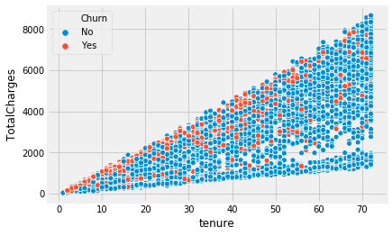

```python
ax = sns.scatterplot(x='tenure', y='TotalCharges', hue='Churn', data=df)
```

- Customers who churn typically pay quite a lot one throughout their tenure with the company.

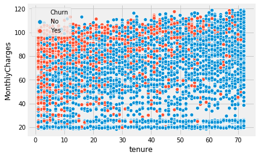

```python
ax = sns.scatterplot(x='tenure', y='MonthlyCharges', hue='Churn', data=df)
```

- New churned customers tend to pay higher monthly charges compared to retained customers.

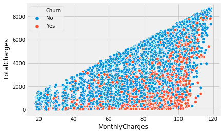

```python
ax = sns.scatterplot(x='MonthlyCharges', y='TotalCharges', hue='Churn', data=df)
```

- Total charges will be less since they leave early too.
- Monthly charges for churned customers are high
- Will create segments based on tenure and analyze them.

```python
tel_df = df.copy()

trace1 = go.Scatter3d(x = churn["MonthlyCharges"],
                      y = churn["TotalCharges"],
                      z = churn["tenure"],
                      mode = "markers",
                      name = "Churned customers",
                      text = "Id : " + churn["customerID"],
                      marker = dict(size = 1,color = "red")
                     )
trace2 = go.Scatter3d(x = retained["MonthlyCharges"],
                      y = retained["TotalCharges"],
                      z = retained["tenure"],
                      name = "Retained customers",
                      text = "Id : " + retained["customerID"],
                      mode = "markers",
                      marker = dict(size = 1,color= "green")
                     )



layout = go.Layout(dict(title = "Monthly charges,Total Charges & Tenure in Customer Attrition",
                        scene = dict(camera = dict(up=dict(x= 0 , y=0, z=0),
                                                   center=dict(x=0, y=0, z=0),
                                                   eye=dict(x=1.25, y=1.25, z=1.25)),
                                     xaxis  = dict(title = "Monthly Charges",
                                                   gridcolor='rgb(255, 255, 255)',
                                                   zerolinecolor='rgb(255, 255, 255)',
                                                   showbackground=True,
                                                   backgroundcolor='rgb(230, 230,230)'),
                                     yaxis  = dict(title = "Total Charges",
                                                   gridcolor='rgb(255, 255, 255)',
                                                   zerolinecolor='rgb(255, 255, 255)',
                                                   showbackground=True,
                                                   backgroundcolor='rgb(230, 230,230)'
                                                  ),
                                     zaxis  = dict(title = "Tenure",
                                                   gridcolor='rgb(255, 255, 255)',
                                                   zerolinecolor='rgb(255, 255, 255)',
                                                   showbackground=True,
                                                   backgroundcolor='rgb(230, 230,230)'
                                                  )
                                    ),
                        height = 700,
                       )
                  )


data = [trace1,trace2]
fig = go.Figure(data = data,layout = layout)
plotly.offline.iplot(fig, show_link=False, config=dict(displaylogo=False, modeBarButtonsToRemove=['sendDataToCloud']))

# Output as Html page div
# Needs externally sourced Plotly JS code
# The JS code if provided in the output
# Make sure the plotly-latest-min.js file is in the same folder as the graph(Html page); to make it run
if get_div_output == True:
    barplot = plotly.offline.plot(fig,
                            config={'displayModeBar': False},
                            show_link=False,
                            include_plotlyjs=False,
                            output_type='div')


    html_string = '''
    <html>
        <head>
            <script src='plotly-latest.min.js'></script>
            <link rel="stylesheet" href="https://maxcdn.bootstrapcdn.com/bootstrap/4.0.0/css/bootstrap.min.css"
            integrity="sha384-Gn5384xqQ1aoWXA+058RXPxPg6fy4IWvTNh0E263XmFcJlSAwiGgFAW/dAiS6JXm" crossorigin="anonymous">
            <style>body{ margin:0 100; background:whitesmoke; }</style>
        </head>
        <body>
            ''' + barplot + '''
        </body>
    </html>'''

    with open('../Graphs/3d.html', 'w') as f:
        f.write(html_string)
```

[interactive chart not shown]

# Creating Tenures Features

```python
def create_sub_tenures(df) :
    # Tenure less than or equal to 12 months
    if df["tenure"] <= 12 :
        return "Tenure_0_12"
    # 13 to 24 months
    elif (df["tenure"] > 12) & (df["tenure"] <= 24 ):
        return "Tenure_13_24"
    # 25 months to 48 months
    elif (df["tenure"] > 24) & (df["tenure"] <= 48) :
        return "Tenure_25_48"
    # 49 months to 60 months
    elif (df["tenure"] > 48) & (df["tenure"] <= 60) :
        return "Tenure_49_60"
    # greater than 60 months
    elif df["tenure"] > 60 :
        return "Tenure_gt_60"
```

```python
df["tenure_group"] = df.apply(lambda df:create_sub_tenures(df),
                                      axis = 1)
```

```python
#Separating churned and retained customers
churn     = df[df["Churn"] == "Yes"]
retained = df[df["Churn"] == "No"]

#Separating catagorical and numerical columns
id_col     = ['customerID']
target_col = ["Churn"]
cat_cols   = df.nunique()[df.nunique() < 6].keys().tolist()
cat_cols   = [x for x in cat_cols if x not in target_col]
num_cols   = [x for x in df.columns if x not in cat_cols + target_col + id_col]
```

# Tenure Groups

```python
# Cusomer attrition in tenure groups
tg_churned  =  churn["tenure_group"].value_counts().reset_index()
tg_churned.columns  = ["tenure_group","count"]
tg_retained =  retained["tenure_group"].value_counts().reset_index()
tg_retained.columns = ["tenure_group","count"]

# Trace Bar - churn
trace1 = go.Bar(x = tg_churned["tenure_group"]  , y = tg_churned["count"],
                name = "Churned Customers",
                marker = dict(color = 'rgba(222,45,38,0.8)', line = dict(width = .5,color = "black")),
                opacity = 1)

# Trace Bar - retained
trace2 = go.Bar(x = tg_retained["tenure_group"] , y = tg_retained["count"],
                name = "Retained Customers",
                marker = dict(color = 'rgb(26, 118, 255)', line = dict(width = .5,color = "white")),
                opacity = 1)

layout = go.Layout(dict(title = "Customer Attrition - Tenure Based",
                        barmode='stack',
                        plot_bgcolor  = "rgb(243,243,243)",
                        paper_bgcolor = "rgb(243,243,243)",
                        xaxis = dict(gridcolor = 'rgb(255, 255, 255)',
                                     title = "Tenure Group (In Months)",
                                     zerolinewidth=1,ticklen=5,gridwidth=2),
                        yaxis = dict(gridcolor = 'rgb(255, 255, 255)',
                                     title = "Number of Customers",
                                     zerolinewidth=1,ticklen=5,gridwidth=2),
                       )
                  )
data = [trace1,trace2]
fig = go.Figure(data = data,layout = layout)
plotly.offline.iplot(fig, show_link=False, config=dict(displaylogo=False, modeBarButtonsToRemove=['sendDataToCloud']))
```

[interactive chart not shown]

- As before, maximum churn in the first year.
- After the second year, churn decreases linearly

## Analyzing Tenure_0_12

```python
df_0_12_tenure = df.loc[df['tenure_group'] == 'Tenure_0_12']
```

```python
df_0_12_tenure.head().T
```

|  | 9 | 11 | 12 | 13 | 18 |
| --- | --- | --- | --- | --- | --- |
| customerID | 4190-MFLUW | 8779-QRDMV | 1680-VDCWW | 1066-JKSGK | 8665-UTDHZ |
| gender | Female | Male | Male | Male | Male |
| SeniorCitizen | No | Yes | No | No | No |
| Partner | Yes | No | Yes | No | Yes |
| Dependents | Yes | No | No | No | Yes |
| tenure | 10 | 1 | 12 | 1 | 1 |
| PhoneService | Yes | No | Yes | Yes | No |
| MultipleLines | No | No phone service | No | No | No phone service |
| InternetService | DSL | DSL | No | No | DSL |
| OnlineSecurity | No | No | No internet service | No internet service | No |
| OnlineBackup | No | No | No internet service | No internet service | Yes |
| DeviceProtection | Yes | Yes | No internet service | No internet service | No |
| TechSupport | Yes | No | No internet service | No internet service | No |
| StreamingTV | No | No | No internet service | No internet service | No |
| StreamingMovies | No | Yes | No internet service | No internet service | No |
| Contract | Month-to-month | Month-to-month | One year | Month-to-month | Month-to-month |
| PaperlessBilling | No | Yes | No | No | No |
| PaymentMethod | Credit card (automatic) | Electronic check | Bank transfer (automatic) | Mailed check | Electronic check |
| MonthlyCharges | 55.2 | 39.65 | 19.8 | 20.15 | 30.2 |
| TotalCharges | 528.35 | 39.65 | 202.25 | 20.15 | 30.2 |
| Churn | Yes | Yes | No | Yes | Yes |
| tenure_group | Tenure_0_12 | Tenure_0_12 | Tenure_0_12 | Tenure_0_12 | Tenure_0_12 |

```python
#Separating churned and retained customers
churn_tenure_0_12     = df_0_12_tenure[df_0_12_tenure["Churn"] == "Yes"]
retained_tenure_0_12 = df_0_12_tenure[df_0_12_tenure["Churn"] == "No"]
```

```python
def plot_pie_tenure_0_12(column) :

    # Churn
    trace1 = go.Pie(values  = churn_tenure_0_12[column].value_counts().values.tolist(),
                    labels  = churn_tenure_0_12[column].value_counts().keys().tolist(),
                    hoverinfo = "label+percent+name",
                    domain  = dict(x = [0,.48]),
                    name    = "Churn Customers",
                    marker  = dict(colors =  ['#003f5c', '#7a5195', '#ef5675', '#ffa600'],line = dict(width = 2,
                                               color = "rgb(243,243,243)")
                                  ),
                    hole    = .6
                   )
    # Retained
    trace2 = go.Pie(values  = retained_tenure_0_12[column].value_counts().values.tolist(),
                    labels  = retained_tenure_0_12[column].value_counts().keys().tolist(),
                    hoverinfo = "label+percent+name",
                    marker  = dict(line = dict(width = 2,
                                               color = "rgb(243,243,243)")
                                  ),
                    domain  = dict(x = [.52,1]),
                    hole    = .6,
                    name    = "Retained customers"
                   )


    layout = go.Layout(dict(title = column.title() + " Distribution In Customer Attrition (First Year) ",
                            plot_bgcolor  = "rgb(243,243,243)",
                            paper_bgcolor = "rgb(243,243,243)",
                            annotations = [dict(text = "Churned",
                                                font = dict(size = 13),
                                                showarrow = False,
                                                x = .20, y = .5),
                                           dict(text = "Retained",
                                                font = dict(size = 14),
                                                showarrow = False,
                                                x = .80,y = .5
                                               )
                                          ]
                           )
                      )
    data = [trace1,trace2]
    fig = go.Figure(data = data,layout = layout)
    plotly.offline.iplot(fig, show_link=False, config=dict(displaylogo=False, modeBarButtonsToRemove=['sendDataToCloud']))
```

# Relation between Numeric Columns and Churn

```python
yes_no = {'No': 0, 'Yes': 1}

data = [
    go.Parcoords(
        line = dict(color = df.index,
                   colorscale = [[0,'red'],[0.25,'#D7C16B'],[0.50,'#23D8C3'],[0.75,'#F3F10F'],[0.75,'crimson']]),
        dimensions = list([
            dict(range = [0,72],
                label = 'Tenure (Months)', values = df['tenure']),
            dict(range = [0,120],
                label = 'Monthly Charges', values = df['MonthlyCharges']),
            dict(range = [0,8800],
                label = 'Total Charges', values = df['TotalCharges']),
            dict(range = [0,1],
                label = 'Churn', values = df['Churn'].map(yes_no),
                ticktext = ['No', 'Yes'], tickvals = [0,1]),
        ])
    )
]

layout = go.Layout(
    paper_bgcolor = 'ghostwhite'
)

fig = go.Figure(data = data, layout = layout)
plotly.offline.iplot(fig, show_link=False, config=dict(displaylogo=False,
                 modeBarButtonsToRemove=['sendDataToCloud']))

# Output as Html page div
# Needs externally sourced Plotly JS code
# The JS code if provided in the output
# Make sure the plotly-latest-min.js file is in the same folder as the graph(Html page); to make it run
if get_div_output == True:
    barplot = plotly.offline.plot(fig,
                            config={'displayModeBar': False},
                            show_link=False,
                            include_plotlyjs=False,
                            output_type='div')


    html_string = '''
    <html>
        <head>
            <script src='plotly-latest.min.js'></script>
            <link rel="stylesheet" href="https://maxcdn.bootstrapcdn.com/bootstrap/4.0.0/css/bootstrap.min.css"
            integrity="sha384-Gn5384xqQ1aoWXA+058RXPxPg6fy4IWvTNh0E263XmFcJlSAwiGgFAW/dAiS6JXm" crossorigin="anonymous">
            <style>body{ margin:0 100; background:whitesmoke; }</style>
        </head>
        <body>
            ''' + barplot + '''
        </body>
    </html>'''

    with open('../Graphs/paracoords.html', 'w') as f:
        f.write(html_string)
```

[interactive chart not shown]

```python
cat_cols
```

```
['gender',
 'SeniorCitizen',
 'Partner',
 'Dependents',
 'PhoneService',
 'MultipleLines',
 'InternetService',
 'OnlineSecurity',
 'OnlineBackup',
 'DeviceProtection',
 'TechSupport',
 'StreamingTV',
 'StreamingMovies',
 'Contract',
 'PaperlessBilling',
 'PaymentMethod',
 'tenure_group']
```

```python
# Creating dimensions
# Churn
yes_no = {'No': 0, 'Yes': 1}
chrun_dim = go.parcats.Dimension(
    values=df['Churn'].map(yes_no),
    categoryarray=[0, 1],
    ticktext=['No', 'Yes'],
    label="Churn"
)

# PhoneService
PhoneService = go.parcats.Dimension(
    values=df['PhoneService'],
    label="Phone Service",
)

# MultipleLines
MultipleLines = go.parcats.Dimension(
    values=df['MultipleLines'],
    label="Muliple Lines"
)

# Create parcats trace
color = df.Churn.map(yes_no);
colorscale = [[0, 'seagreen'], [1, 'Red']];

data = [
    go.Parcats(
        dimensions=[PhoneService,MultipleLines, chrun_dim],
        line={'color': color,
              'colorscale': colorscale},
        hoveron='color',
        hoverinfo='count',
        labelfont={'size': 18, 'family': 'Times'},
        tickfont={'size': 16, 'family': 'Times'},
        arrangement='freeform'
    )
]

layout = go.Layout(
    title="Customer Flow in Phone Services",
    titlefont=dict(
        size=20,
        color='rgb(203,203,203)'
    ),
    font=dict(
                size=16,
                color='#ffffff'
    ),
    showlegend=False,
    paper_bgcolor='rgba(44,58,71,1)',
    plot_bgcolor='rgba(44,58,71,1)',
    xaxis=dict(
        showticklabels=False,
        zeroline=False,
    ),
    yaxis=dict(
        showticklabels=False,
        zeroline=False
    )
)

fig = go.Figure(data = data, layout = layout)
plotly.offline.iplot(fig, show_link=False, config=dict(displaylogo=False,
                 modeBarButtonsToRemove=['sendDataToCloud']))
```

[interactive chart not shown]

```python
# Creating dimensions
# Churn
yes_no = {'No': 0, 'Yes': 1}
chrun_dim = go.parcats.Dimension(
    values=df['Churn'].map(yes_no),
    categoryarray=[0, 1],
    ticktext=['No', 'Yes'],
    label="Churn"
)

# InternetService
InternetService_dim = go.parcats.Dimension(
    values=df['InternetService'],
    label="Internet Service",
)

# OnlineSecurity
OnlineSecurity_dim = go.parcats.Dimension(
    values=df['OnlineSecurity'],
    label="Online Security"
)

# OnlineBackup
OnlineBackup_dim = go.parcats.Dimension(
    values=df['OnlineBackup'],
    label="Online Backup",
)

# DeviceProtection
DeviceProtection_dim = go.parcats.Dimension(
    values=df['DeviceProtection'],
    label="Device Protection"
)
# TechSupport
TechSupport_dim = go.parcats.Dimension(
    values=df['TechSupport'],
    label="Technical Support",
)

# StreamingTV
StreamingTV_dim = go.parcats.Dimension(
    values=df['StreamingTV'],
    label="Streaming TV"
)

# StreamingMovies
StreamingMovies_dim = go.parcats.Dimension(
    values=df['StreamingMovies'],
    label="Streaming Movies"
)


# Create parcats trace
color = df.Churn.map(yes_no);
colorscale = [[0, 'seagreen'], [1, 'Red']];

data = [
    go.Parcats(
        dimensions=[InternetService_dim, OnlineSecurity_dim, OnlineBackup_dim, DeviceProtection_dim, TechSupport_dim, StreamingTV_dim, StreamingMovies_dim, chrun_dim],
        line={'color': color,
              'colorscale': colorscale},
        hoveron='color',
        hoverinfo='count',
        labelfont={'size': 18, 'family': 'Times'},
        tickfont={'size': 16, 'family': 'Times'},
        arrangement='freeform'
    )
]

layout = go.Layout(
    title="Attrition Flow - Internet Services",
    titlefont=dict(
        size=20,
        color='rgb(203,203,203)'
    ),
    font=dict(
                size=16,
                color='#ffffff'
    ),
    showlegend=False,
    paper_bgcolor='rgba(44,58,71,1)',
    plot_bgcolor='rgba(44,58,71,1)',
    xaxis=dict(
        showticklabels=False,
        zeroline=False,
    ),
    yaxis=dict(
        showticklabels=False,
        zeroline=False
    )
)

fig = go.Figure(data = data, layout = layout)
plotly.offline.iplot(fig, show_link=False, config=dict(displaylogo=False,
                 modeBarButtonsToRemove=['sendDataToCloud']))

if get_div_output == True:
    div_chart = plotly.offline.plot(fig,
                            config={'displayModeBar': False},
                            show_link=False,
                            include_plotlyjs=False,
                            output_type='div')


    html_string = '''
    <html>
        <head>
            <script src='plotly-latest.min.js'></script>
            <link rel="stylesheet" href="https://maxcdn.bootstrapcdn.com/bootstrap/4.0.0/css/bootstrap.min.css"
            integrity="sha384-Gn5384xqQ1aoWXA+058RXPxPg6fy4IWvTNh0E263XmFcJlSAwiGgFAW/dAiS6JXm" crossorigin="anonymous">
            <style>body{ margin:0 100; background:whitesmoke; }</style>
        </head>
        <body>
            ''' + div_chart + '''
        </body>
    </html>'''

    with open('../Graphs/share_churn_retained.html', 'w') as f:
        f.write(html_string)
```

[interactive chart not shown]